# Homework #11

Robert Campbell

10 May 2021

## Chapter 12

### Problem 04

1. Looks like the data satisfies ANOVA assumptions

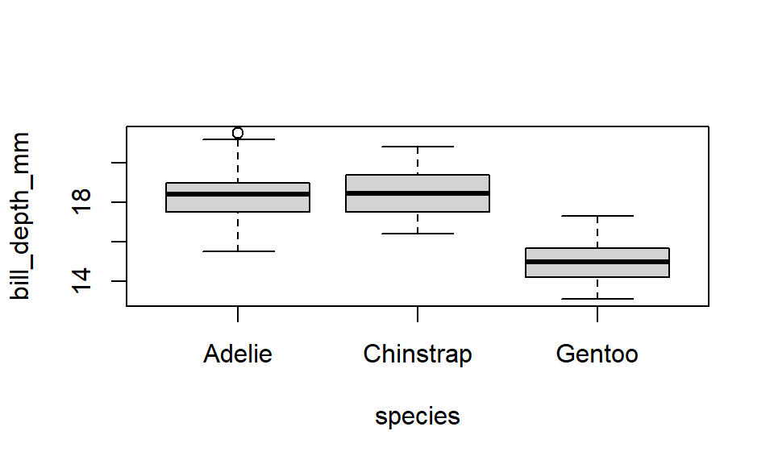

```r
pen<-palmerpenguins::penguins
boxplot(bill_depth_mm ~ species, data=pen)
```

2. p-value < 2.2*(10^-16), showing significance at the alpha = 0.01 level. Reject the null, species does significantly predict bill depth.

```r
depth_mod<-lm(bill_depth_mm ~ species, data=pen)
anova(depth_mod)
```

```
## Analysis of Variance Table
##
## Response: bill_depth_mm
##            Df Sum Sq Mean Sq F value    Pr(>F)
## species     2 903.97  451.98  359.79 < 2.2e-16 ***
## Residuals 339 425.87    1.26
## ---
## Signif. codes:  0 '***' 0.001 '**' 0.01 '*' 0.05 '.' 0.1 ' ' 1
```

### Problem 05

P-value: 0.00362, reject the null. There are significant differences in the predictions of 300g objects by age group.

```r
anova(lm(mean300 ~ age, data=fosdata::weight_estimate))
```

```
## Analysis of Variance Table
##
## Response: mean300
##           Df Sum Sq Mean Sq F value  Pr(>F)
## age        3  60786 20262.1  4.9018 0.00362 **
## Residuals 76 314155  4133.6
## ---
## Signif. codes:  0 '***' 0.001 '**' 0.01 '*' 0.05 '.' 0.1 ' ' 1
```

### Problem 06

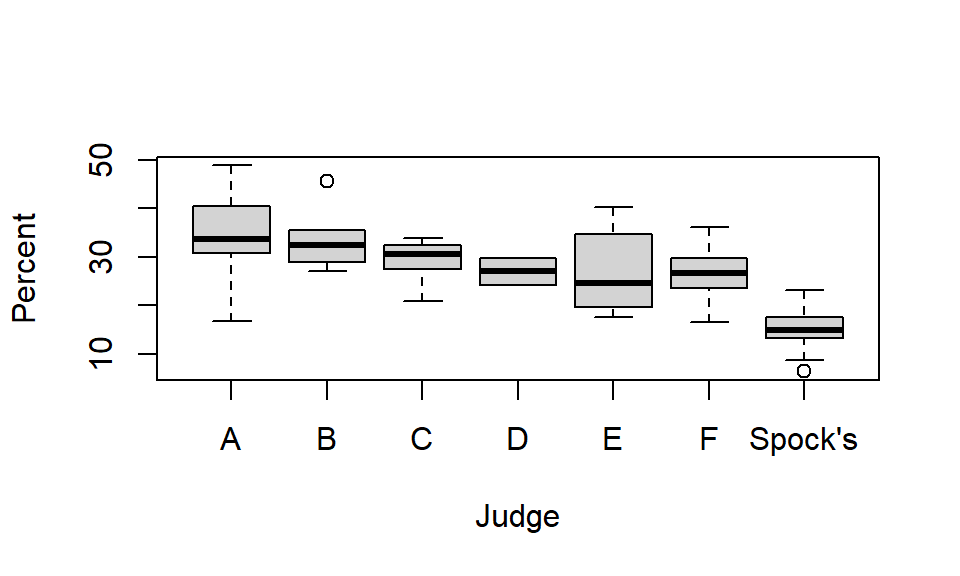

```r
judge_perc <- Sleuth3::case0502
boxplot(Percent ~ Judge, data=judge_perc)
```

b. P-value: 0.3239, do not reject the null. The means of the percentage of women jurors in the 6 other judges courts are significantly similar.

```r
judge_perc %>% filter(Judge != "Spock's") %>% lm(Percent ~ Judge, data=.) %>% anova()
```

```
## Analysis of Variance Table
##
## Response: Percent
##           Df  Sum Sq Mean Sq F value Pr(>F)
## Judge      5  326.46  65.292  1.2183 0.3239
## Residuals 31 1661.33  53.591
```

3. The significantly similar means of the other judges justifies comparing Spock’s judge to the other 6. P-value: 1.303 * (10^-6), reject the null. There is significant difference in the expected percentage of women jurors in Spock’s judge’s court when compared to the other judges.

```r
judge_perc %>% mutate(Spock = (Judge=="Spock's")) %>%
  t.test(Percent ~ Spock, data=.)
```

```
##
##  Welch Two Sample t-test
##
## data:  Percent by Spock
## t = 7.1597, df = 17.608, p-value = 1.303e-06
## alternative hypothesis: true difference in means is not equal to 0
## 95 percent confidence interval:
##  10.49935 19.23999
## sample estimates:
## mean in group FALSE  mean in group TRUE
##            29.49189            14.62222
```

### Problem 08

The p-value: 5.93*(10^-10) looks to show significant difference in weight based on feed, however the bloxplot shows inconsistent variance in the different groups with the most extreme being when you compare “meatmeal” with “sunflower”.

```r
anova(lm(weight ~ feed, data=chickwts))
```

```
## Analysis of Variance Table
##
## Response: weight
##           Df Sum Sq Mean Sq F value    Pr(>F)
## feed       5 231129   46226  15.365 5.936e-10 ***
## Residuals 65 195556    3009
## ---
## Signif. codes:  0 '***' 0.001 '**' 0.01 '*' 0.05 '.' 0.1 ' ' 1
```

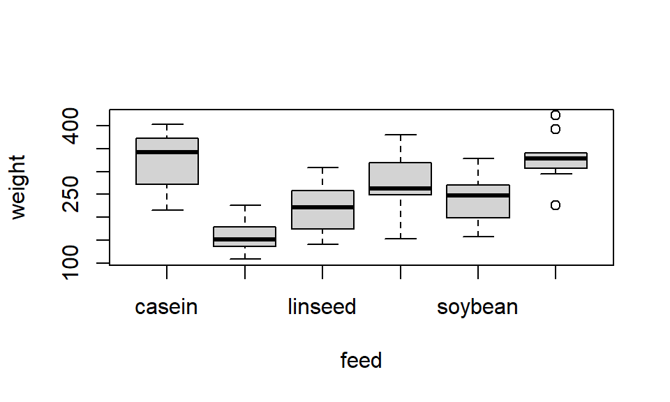

```r
boxplot(weight ~ feed, data=chickwts)
```

### Problem 09

With P-value: 0.0004827, it looks like there is significant difference in the mean based on experiment number. However, looking at the boxplots the data does not satisfy the anova assumptions, especially experiments 3 and 5.

```r
anova(lm(Speed ~ Expt, data=morley))
```

```
## Analysis of Variance Table
##
## Response: Speed
##           Df Sum Sq Mean Sq F value    Pr(>F)
## Expt       1  72581   72581  13.041 0.0004827 ***
## Residuals 98 545444    5566
## ---
## Signif. codes:  0 '***' 0.001 '**' 0.01 '*' 0.05 '.' 0.1 ' ' 1
```

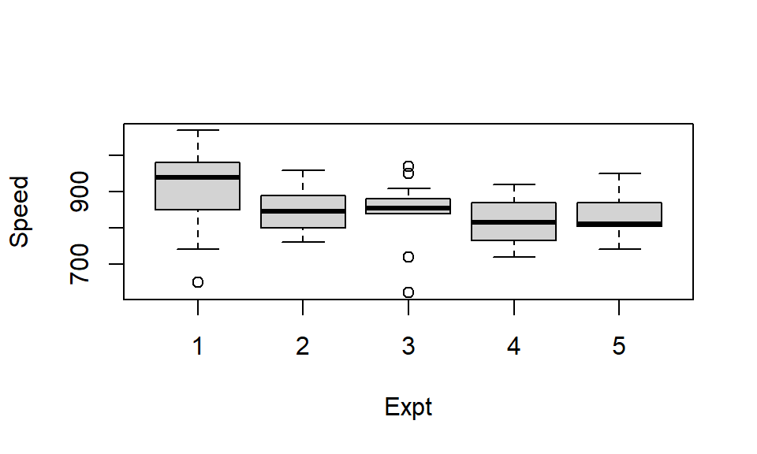

```r
boxplot(Speed ~ Expt, data=morley)
```

### Problem 15

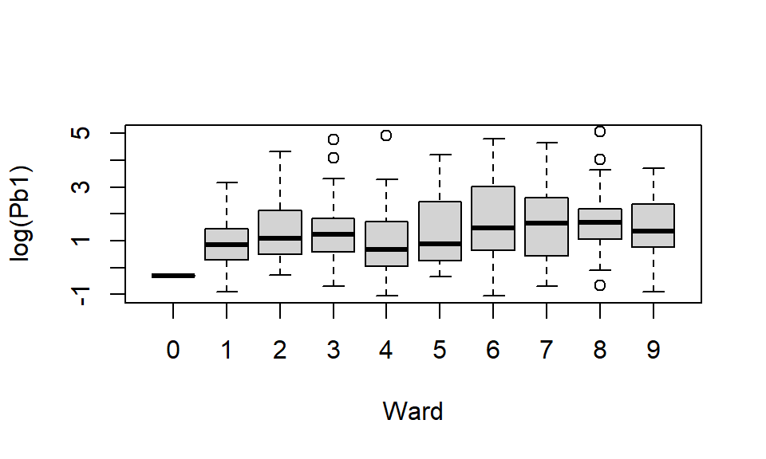

```r
flint_pb <- fosdata::flint
boxplot(log(Pb1) ~ Ward, data=flint_pb)
```

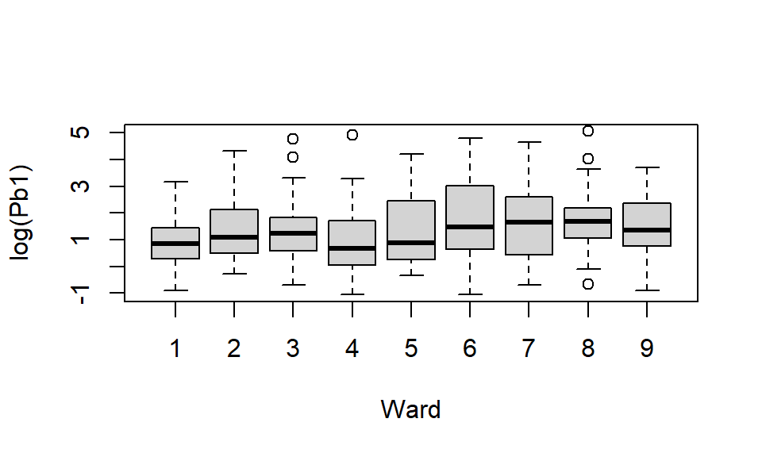

```r
flint_pb<- flint_pb %>% filter(Ward != 0)
boxplot(log(Pb1) ~ Ward, data=flint_pb)
```

b. The log levels look normally distributed and the variances a similar enough to justify anova.  
c. P-value: 0.03137, there is a significant difference in the mean of the log of the amount of lead in the water based on ward in Flint, MI.

```r
anova(lm(log(Pb1) ~ Ward, data=flint_pb))
```

```
## Analysis of Variance Table
##
## Response: log(Pb1)
##            Df Sum Sq Mean Sq F value  Pr(>F)
## Ward        1   7.76  7.7563  4.6815 0.03137 *
## Residuals 268 444.03  1.6568
## ---
## Signif. codes:  0 '***' 0.001 '**' 0.01 '*' 0.05 '.' 0.1 ' ' 1
```